# Restaurant Sanitation Inspections Case Study

An analysis to uncover the **key factors** driving **low sanitation scores** for restaurants in Charlotte, North Carolina

Morgan Heinly

December 12, 2021

# 1 Business Problem

**Food establishments lack clear and concise guidance** required to adequately prepare for sanitation inspections, leading to **poor sanitation scores** from local health inspectors. Low scores can result in:

- Corrosion of customer trust and reputational damage
- Expensive fines and costly remediation efforts
- Inability to operate due to permit revocation / non-issuance
- High litigation costs if lawsuits are pursued by employees, government entities, or customers

# 2 Background

## 2.1 Inspection Authorities

The Food and Drug Administration (FDA) provides guidance to approximately 75 state and territorial agencies and more than 3,000 local departments that assume primary responsibility for preventing food borne illnesses, issuing licenses, and inspecting establishments within the retail food industry.

In the state of North Carolina, the Department of Health and Human Services (DHHS) is responsible for protecting the health, welfare, and economic interests of food consumers. The department has formalized its own food code manual and standardized framework (derived from the FDA’s 2017 food code) for assessing food establishments. The official N.C. food code manual can be found [here](https://ehs.ncpublichealth.com/faf/docs/foodprot/NC-FoodCodeManual-2021-FINAL.pdf).

## 2.2 Restaurant Inspections

The DHHS evaluates restaurants by performing bi-annual (and sometimes unannounced) sanitation inspections to ensure compliance with standards outlined in North Carolina’s code manual. Rules governing inspections, including grading system and public display requirements can be found [here](https://public.cdpehs.com/NCENVPBL/ESTABLISHMENT/ShowRestaurantRules.aspx).

# 3 Project Overview

## 3.1 Summary

Restaurants (the primary category of food establishments) should strive to achieve high sanitation inspection scores from local authorities; but even more importantly, they must avoid low sanitation scores, which can have significant business implications.

In many circumstances, restaurants must thoroughly review numerous compliance documents (including the ~240 page code manual) to adequately prepare for sanitation inspections. However, this can be a time-consuming and ambiguous process! Furthermore, restaurants may not know the severity of violation types and specific codes that are most important to comply with, leading to confusion when determining which code sections to prioritize for inspection readiness.

## 3.2 Purpose

The objective of this analysis will be to extract and analyze publicly available inspection data to:

1. Identify and highlight the driving factors causing lower sanitation scores
2. Provide succinct guidance and recommendations for both new and existing restaurants to reference when preparing for their inspections

## 3.3 Scope

- Restaurants located in Charlotte, NC (Mecklenburg Country)
- Inspections range from Jan 2017- Oct 2021

## 3.4 Data

1. Source

Data for reported restaurant inspection scores can typically be accessed through city data portals or government websites, which are authorized to publish such information.

*Inspection report data for Charlotte, NC can be accessed through Mecklenburg County’s government website at MECKNC.GOV and accessing CDP’s Inspection Management system* [here](https://public.cdpehs.com/NCENVPBL/ESTABLISHMENT/ShowESTABLISHMENTTablePage.aspx?ESTTST_CTY=60)

2. Collection Process

Inspection reports were stored in a dynamic hierarchical table which used XHTML, Java Script, and embedded programmatic calls, which presented some challenges to extracting the data en masse.

Due to this data storage complexity, an RPA tool (UiPath) was configured to:

1. Batch processes each restaurant within the inspection management system website
2. Extract tables for restaurant information, inspection data, and violation data for each record
3. Relate each entity table using unique identifiers captured and assigned by the RPA tool
4. Synthesize data and prepare for analysis using R Studio

*For technical details on data extraction process, see Section 7.2 Appendix B*

# 4 Analysis

## 4.1 Tables and Records

Included in our analysis:

We have 3 tables: Restaurants, Inspections, and Violations.

Each restaurant is related to **one or many inspections** and each inspection is related to **zero, one, or many violations**.

- Total restaurants: 934
- Total inspections: 8,992
- Total violations: 45,471

## 4.2 Data Dictionary

A data dictionary describes the tables in our analysis and the fields within each table, e.g., data types, descriptions, etc.

Data Dictionary

| # | Table Name | Field Name | Field Type | Field Description |
| --- | --- | --- | --- | --- |
| 1 | restaurants | est_id | char | restaurant ID determined by city inspection authorities |
| 2 | restaurants | name | char | name of the restaurant in Charlotte, NC |
| 3 | restaurants | address | char | address of the restaurant in Charlotte, NC |
| 4 | restaurants | city | char | city of the restaurant (always Charlotte, but included for mapping) |
| 5 | restaurants | state | char | state (always NC, but included for mapping) |
| 6 | restaurants | zip | char | zip code of the restaurant in Charlotte, NC |
| 1 | inspections | est_id | char | restaurant ID determined by city inspection authorities |
| 2 | inspections | inspection_id | char | inspection ID determined by city inspection authorities |
| 3 | inspections | inspection_date | date | inspection date |
| 4 | inspections | inspection_score | numeric | inspection score determined by city inspection authorities |
| 5 | inspections | inspection_grade | char | inspection score determined by city inspection authorities |
| 6 | inspections | inspector_id | char | inspector ID |
| 1 | violations | est_id | char | restaurant ID determined by city inspection authorities |
| 2 | violations | inspection_id | char | inspection ID determined by city inspection authorities |
| 3 | violations | violation_item | numeric | violation item corresponding with city standards |
| 4 | violations | demerits | numeric | demerits received for each violation item |
| 5 | violations | violation_description | char | description of violation |
| 6 | violations | corrected_during_inspection | char | whether the violation was corrected at the time of inspection |
| 7 | violations | repeat_violation | char | whether the violation was repeated from prior inspection |
| 8 | violations | verification_required | char | whether verification was required or not |
| 9 | violations | inspector_comments | char | inspector comments for each violation item |

## 4.3 Data View & Summary Statistics *(optional section)*

TABLE 1: RESTAURANTS

| est_id | name | address | city | state | zip |
| --- | --- | --- | --- | --- | --- |
| 247773 | 10 PARK LANES | 1700 MONTFORD DR | CHARLOTTE | NC | 28209 |
| 127669 | 131 MAIN | 9886 REA RD | CHARLOTTE | NC | 28277 |
| 210490 | 131 MAIN SOUTHPARK | 5970 FAIRVIEW RD | CHARLOTTE | NC | 28211 |
| 165868 | 1897 MARKET | 5501 JOSH BIRMINGHAM PARKWAY | CHARLOTTE | NC | 28208 |
| 125254 | 1900 MEXICAN GRILL | 5110 PARK RD | CHARLOTTE | NC | 28209 |
| 128509 | 1900 MEXICAN GRILL | 1523 ELIZABETH AV | CHARLOTTE | NC | 28204 |
| 223352 | 1ST AND GOAL | 7801 UNIVERSITY CITY BV | CHARLOTTE | NC | 28213 |
| 173566 | 204 N TRYON KITCHEN & COCKTAILS | 204 N TRYON ST | CHARLOTTE | NC | 28202 |
| 210018 | 500 DEGREES PIZZERIA | 6037 SOUTH BV | CHARLOTTE | NC | 28217 |
| 129447 | 5CHURCH RESTAURANT | 127 N TRYON ST | CHARLOTTE | NC | 28202 |

[output cut: 90 more lines]

```
## -- Data Summary ------------------------
##                            Values
## Name                       restaurants_final
## Number of rows             934
## Number of columns          6
## _______________________
## Column type frequency:
##   character                6
## ________________________
## Group variables            None
##
## -- Variable type: character ----------------------------------------------------
## # A tibble: 6 x 8
##   skim_variable n_missing complete_rate   min   max empty n_unique whitespace
## * <chr>             <int>         <dbl> <int> <int> <int>    <int>      <int>
## 1 est_id                0             1     6     6     0      934          0
## 2 name                  0             1     2    50     0      892          0
## 3 address               0             1    11    36     0      825          0
## 4 city                  0             1     9     9     0        1          0
## 5 state                 0             1     2     2     0        1          0
## 6 zip                   0             1     5     5     0       31          0
```

TABLE 2: INSPECTIONS

| est_id | inspection_id | inspection_date | inspection_score | inspection_grade | inspector_id |
| --- | --- | --- | --- | --- | --- |
| 247773 | 3930061 | 2021-10-14 | 97.0 | A | 3000 |
| 127669 | 3924269 | 2021-09-29 | 96.0 | A | 948 |
| 127669 | 3742903 | 2021-06-15 | 97.0 | A | 2805 |
| 127669 | 3698517 | 2021-01-19 | 97.5 | A | 2805 |
| 127669 | 3621324 | 2020-08-03 | 95.0 | A | 2805 |
| 127669 | 3555900 | 2019-11-25 | 96.0 | A | 2805 |
| 127669 | 3434942 | 2019-07-22 | 97.5 | A | 2805 |
| 127669 | 3393768 | 2019-03-27 | 97.0 | A | 2398 |
| 127669 | 3337584 | 2018-10-10 | 96.0 | A | 2398 |
| 127669 | 3288373 | 2018-05-16 | 95.0 | A | 2398 |

[output cut: 90 more lines]

```
## -- Data Summary ------------------------
##                            Values
## Name                       (inspections %>% select(-...
## Number of rows             8992
## Number of columns          6
## _______________________
## Column type frequency:
##   character                4
##   numeric                  1
##   POSIXct                  1
## ________________________
## Group variables            None
##
## -- Variable type: character ----------------------------------------------------
## # A tibble: 4 x 8
##   skim_variable    n_missing complete_rate   min   max empty n_unique whitespace
## * <chr>                <int>         <dbl> <int> <int> <int>    <int>      <int>
## 1 est_id                   0             1     6     6     0     1174          0
## 2 inspection_id            0             1     7     7     0     8992          0
## 3 inspection_grade         0             1     1     1     0        3          0
## 4 inspector_id             0             1     1     4     0       85          0
##
## -- Variable type: numeric ------------------------------------------------------
## # A tibble: 1 x 11
##   skim_variable    n_missing complete_rate  mean    sd    p0   p25   p50   p75
## * <chr>                <int>         <dbl> <dbl> <dbl> <dbl> <dbl> <dbl> <dbl>
## 1 inspection_score         0             1  95.9  2.61    70    95  96.5    98
##    p100 hist
## * <dbl> <chr>
## 1   100 ▁▁▁▂▇
##
## -- Variable type: POSIXct ------------------------------------------------------
## # A tibble: 1 x 7
##   skim_variable   n_missing complete_rate min
## * <chr>               <int>         <dbl> <dttm>
## 1 inspection_date         0             1 2017-01-03 00:00:00
##   max                 median              n_unique
## * <dttm>              <dttm>                 <int>
## 1 2021-10-22 00:00:00 2019-12-11 00:00:00     1175
```

TABLE 3: VIOLATIONS

| est_id | inspection_id | violation_item | demerits | violation_description | corrected_during_inspection | repeat_violation | verification_required | inspector_comments |
| --- | --- | --- | --- | --- | --- | --- | --- | --- |
| 247773 | 3930061 | 5 | 0.0 | Procedures for responding to vomiting & diarrheal events | Yes | No | No | 2-501.11 Clean-up of Vomiting and Diarrheal Event. CDI - EHS provided education on establishment requirement of Vomit & Diarrheal Written Plan and Clean-Up kit. Guidance has been provided to email add… |
| 247773 | 3930061 | 10 | 0.0 | Handwashing sinks supplied & accessible | Yes | No | No | 5-205.11 Maintain access to handsinks. Handsinks may only be used for handwashing.-Pf. Observed tall standing fan obstructing hand sink across from 3-compartment sink. CDI - Obstruction removed. |
| 247773 | 3930061 | 16 | 1.5 | Food-contact surfaces: cleaned & sanitized | Yes | No | No | 4-501.114 Maintain sanitizer at correct concentrations when being used to sanitize. -P. Observed Quat sanitizer at dispenser at 3-compartment sink at 0-50 ppm. CDI - PIC contacted Ecolab repair techni… |
| 247773 | 3930061 | 23 | 0.0 | Proper date marking & disposition | Yes | No | No | 3-501.18 Discard the food requiring date labels once time/temperature window has expired, if it is not been labeled, or if the label is incorrect. -P. Observed cut lettuce over 7 day date mark require… |
| 247773 | 3930061 | 28 | 1.0 | Toxic substances properly identified stored & used | Yes | No | No | 7-102.11 Label working containers of toxic materials such as cleaners and sanitizers.-Pf. Observed unlabeled bottle of cleaning agent in bar area. PIC could not determine cleaning agent. CDI - PIC vol… |
| 247773 | 3930061 | 37 | 0.0 | Food properly labeled: original container | No | No | No | 3-302.12 Label all working containers of food (oils, spices, salts) except food that is easy to identify such as dry pasta. Observed several unlabeled squeeze bottles throughout facility. |
| 247773 | 3930061 | 48 | 0.5 | Warewashing facilities: installed, maintained & used; test strips | Yes | No | No | 4-302.14 Provide a test kit that accurately measures sanitizer concentrations. -Pf. Observed Quat test strips unable to detect proper sanitizer concentration due to kit being water damaged. CDI - PIC … |
| 247773 | 3930061 | 49 | 0.0 | Non-food contact surfaces clean | No | No | No | 4-601.11 (B) and (C) Equipment, Food-Contact Surfaces, Nonfood-Contact Surfaces, and Utensils - C. Observed several cambros stored as clean with labels present on exterior non-food contact surface. |
| 247773 | 3930061 | 54 | 0.0 | Garbage & refuse properly disposed; facilities maintained | No | No | No | 5-501.113(B) Keep dumpster, outside waste containers covered with tight-fitting lids or doors. Observed cardboard and dumpster sliding doors left open. 5-501.115 Maintaining Refuse Areas and Enclosure… |
| 127669 | 3924269 | 8 | 0.0 | Handwashing sinks, supplied and accessible | Yes | No | No | 6-301.12 Provide paper towels or approved alternative for hand drying at each handsink. -Pf One kitchen hand sink with no hand towels; CDI by placing towels in dispenser. |

[output cut: 90 more lines]

```
## -- Data Summary ------------------------
##                            Values
## Name                       violations
## Number of rows             45471
## Number of columns          9
## _______________________
## Column type frequency:
##   character                7
##   numeric                  2
## ________________________
## Group variables            None
##
## -- Variable type: character ----------------------------------------------------
## # A tibble: 7 x 8
##   skim_variable               n_missing complete_rate   min   max empty n_unique
## * <chr>                           <int>         <dbl> <int> <int> <int>    <int>
## 1 est_id                              0             1     6     6     0     1041
## 2 inspection_id                       0             1     7     7     0     8186
## 3 violation_description               0             1    20   106     0       86
## 4 corrected_during_inspection         0             1     2     3     0        2
## 5 repeat_violation                    0             1     2     3     0        2
## 6 verification_required               0             1     2     3     0        2
## 7 inspector_comments                  0             1     1  1977     0    44478
##   whitespace
## *      <int>
## 1          0
## 2          0
## 3          0
## 4          0
## 5          0
## 6          0
## 7          0
##
## -- Variable type: numeric ------------------------------------------------------
## # A tibble: 2 x 11
##   skim_variable  n_missing complete_rate   mean     sd    p0   p25   p50   p75
## * <chr>              <int>         <dbl>  <dbl>  <dbl> <dbl> <dbl> <dbl> <dbl>
## 1 violation_item         0             1 29.7   15.4       1    18  31    43
## 2 demerits               0             1  0.739  0.829     0     0   0.5   1.5
##    p100 hist
## * <dbl> <chr>
## 1    56 ▃▇▂▇▅
## 2     4 ▇▅▁▁▁
```

## 4.4 Data Exploration

Before diving into the data, let’s quickly take a moment to review the grading scale and scoring methodology.

Grading Scale:

- Inspection scores directly correspond to inspection Grades
- Grades can either be **A**, **B**, or **C**
- Inspection scores range from 70 (worst) - 100 (best)
- **A:** 100 - 90 **B:** 89 - 80 **C:** 79 - 70

Scoring System:

- All restaurants start with an inspection score of **100**
- For each violation found by the inspector, a **demerit value** is assigned to that violation
- Demerits can be: **0**, **0.5**, **1**, **1.5**, **2**, **3**, or **4**
- Final sanitation inspection score is simply: **100** - **total number of demerits** received during the inspection

### 4.4.1 Map View

Let’s take a quick look at some restaurants in Charlotte.

*If viewed in HTML file, hover over points to see restaurant names or click any of the points to see minimum inspections scores*

This map represents less than half the restaurants in Charlotte; but as depicted below, most are doing fairly well in terms of sanitation inspection ratings. some restaurants such as **Deli La Union**, **Old Pineville Premium Pub**, and **Santa Fe Mexican Restaurant** are clearly establishments to avoid.

[interactive chart not shown]

### 4.4.2 Exploratory Data Analysis (EDA)

Let’s start by visualizing the relationship between inspection scores and number of violations

The below chart shows a scatter plot with splines - as expected, there is clearly a strong negative relationship between number of violations and inspection scores; but these variables are not 100% correlated because violation demerits can range from 0 to 4.

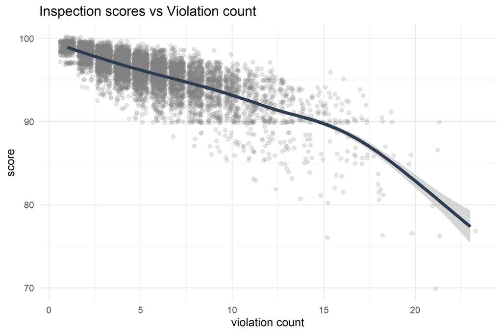

## 4.5 Feature Selection

### 4.5.1 Demerit Analysis

Considering the formula for inspection scores covered in section 4.4, number of demerits for each inspection will be our key focus! As a starting point, there are 3 fields in the violations table that seem like good candidates for investigation.

1. Repeat Violation: Yes/ No
2. Corrected During Inspection: Yes/ No
3. Verification Required: Yes/ No

Let’s see if these contain any useful information by analyzing proportions of Yes vs. No for demerit type

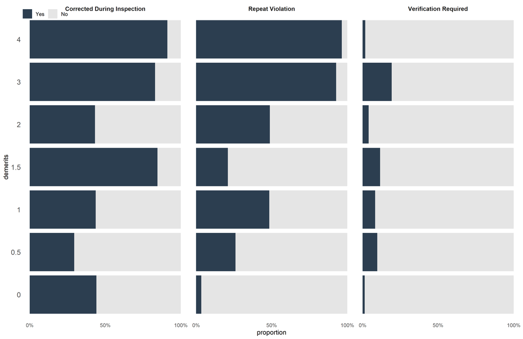

An important takeaway here is: violations with **3** or **4** demerits are typically **repeat violations** and **must be corrected during the inspection.**

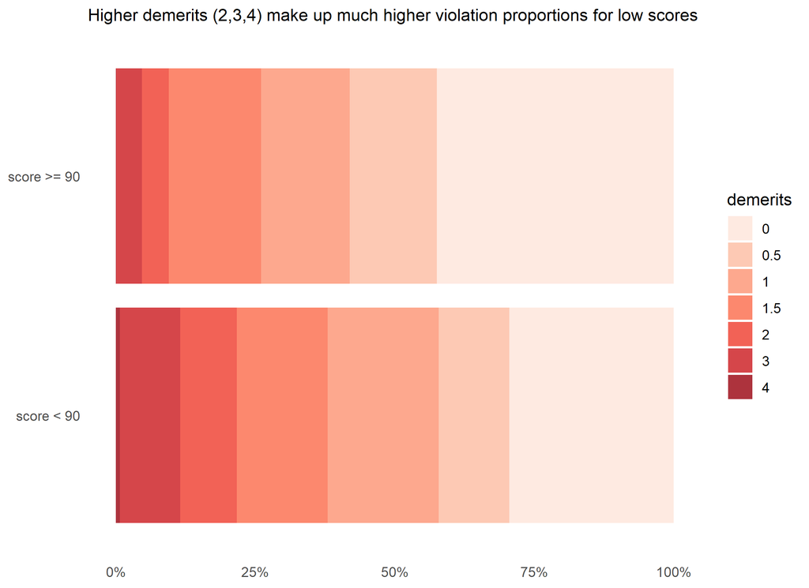

The chart above tells us something interesting about demerit types:

- While violation counts are obviously important, the severity of violations matter significantly
- **High demerits** make up much higher proportions for **lower scores**

*note: while 90 was determine as an initial threshold, more extreme values were sampled for higher and lower scores. Results were the same.*

Now we have a bit more direction for the remainder of our analysis!

### 4.5.2 Violation Descriptions

The violation descriptions (within the violations table) is rich in content and could be useful for the following reasons:

1. The descriptions are short but informative text fields that provide a bit more detail than single values
2. After significant data clean up, only ~ 50 unique descriptions remained, which limited noise in the data

The points in red represent top descriptions contributing to low scores. Shapes denote number of demerits

Note: *hands clean and properly washed* is duplicated because it was the only description containing 4 demerits

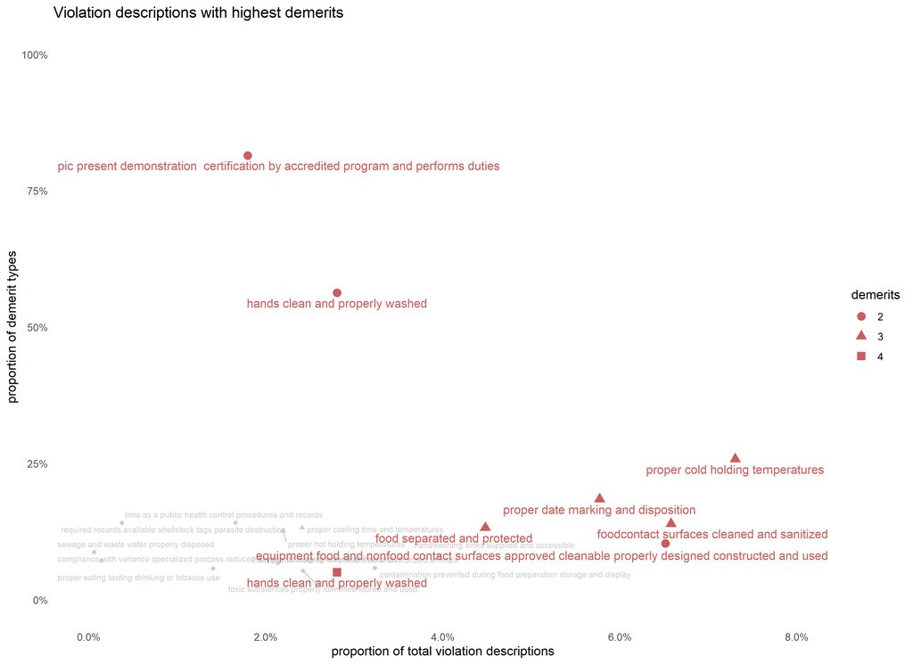

**What is known up to this point?**

1. Higher demerits are typically repeat violations and associated with lower inspection scores
2. Restaurants with low inspection scores typically have more violations and high demerits per violation
3. Certain violation descriptions are associated with lower scores. e.g., hands clean and properly washed, food separated and protected, proper date marking, and proper cold holding temperatures

It’s a good starting point, but how can we better understand what inspectors are saying about each violation? This information can be found in the **inspector comments**.

## 4.6 Natural Language Processing (NLP)

NLP can be a useful tool in when dealing with text data. In this case, the goal is to summarize bits of text that are most associated with lower scores (without having to read thousands of comments).

### 4.6.1 TF-IDF

TF-IDF is a relatively simple, but sometimes powerful technique for understanding words associated with one document vs. another.

Before any NLP can be performed, text data must be be pre-processed, cleaned and normalized. See the full code base in the appendix for more on how this was performed.

**A brief introduction to TF-IDF**

- TF-IDF defines importance of a term by taking into consideration the importance of that term in a single document, and scaling it by its importance across all documents.
- Exact formula can be found in *Appendix A*
- Number of words (ngrams) typically range from 1 to 4. For this analysis we’ll just use one for the preliminary model.

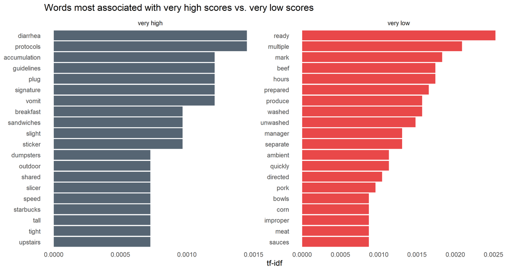

*The actual TF-IDF value is an arbitrary number and does not represent a probability or any statistical metric; rather, it is only used as a benchmark for comparison.*

At first, the results may look a bit surprising and perhaps nebulous.

- **diarrhea**, **protocols**, and **accumulation** are 3 single words most specific to higher inspection scores
- **ready**, **multiple**, and **mark** are more associated with lower inspection scores

However, when we actually read the inspector comments, the results do make sense! For example:

- **vomit** and **protocols** are used to describe the restaurant’s failure to establish vomit clean-up protocols. Same with Diarrhea and most others found by TF-IDF. In general, these are insignificant violations.
- **Ready** is used with many situations to describe consumption ready food, **mark** describes date marking violations and most others describe food preparation and storage. As seen earlier during the data exploration phase, these are usually more serious violations.

These findings confirm much of what we’ve discovered earlier in the analysis, but more information is needed.

### 4.6.2 Text Summary Modeling:

Since the goal is to summarize text for lower sanitation scores, Google’s Page Rank Model was used to extract and understand important text from the inspector comments field. Details on the math behind this model are outside the scope of this analysis. If interested, See [this](https://ipsen.math.ncsu.edu/ps/slides_man.pdf) link for more details.

Model output is depicted in the word cloud below. Phrases with larger font size are most relevant in lower scores.

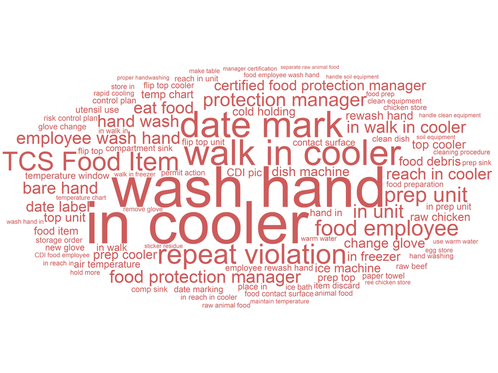

Some key phrases (in inspector comments) associated with lower scores

1. wash hand
2. walk-in cooler
3. date Mark
4. TCS food item
5. repeat violation
6. certified food protection manager

The word cloud and TF-IDF models certainly give us an idea of what inspectors are saying about underperforming restaurants in Charlotte; However, the most important component is still missing - restaurants need to know how these findings relate to critical violation codes and subcodes within North Carolina’s food code manual, which will be the focus of our final section.

## 4.7 Violation Codes

We know that lower sanitation scores (especially scores less than 80) have multiple demerits greater than 1.5 We also confirmed that words and phrases used in inspector comments are highly correlated with higher level demerits (2,3,4). Put simply: restaurants need to avoid violations associated with these demerits!

The following graph shows the **top 10 most critical violation codes** i.e., codes that contribute most to higher demerits.

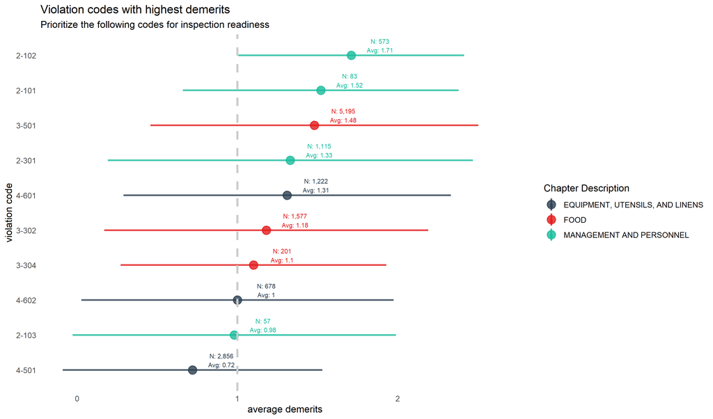

## 4.8 Final Reference Table

Lastly, we’ll go one step further by taking these violation codes and finding the corresponding **subcodes** , which restaurants must comply with in order to avoid higher demerits, and ultimately, low inspection scores.

**Severe Violations Table**

Prioritize these violation codes for inspection readiness

|  | Violation Code | Violation Sub-Code |
| --- | --- | --- |
| CHAPTER 2: MANAGEMENT AND PERSONNEL |  |  |
| 2-1: SUPERVISION | 2-101: RESPONSIBILITY | 2-101.11: ASSIGNMENT |
| 2-1: SUPERVISION | 2-102: KNOWLEDGE | 2-102.11: DEMONSTRATION |
| 2-1: SUPERVISION | 2-102: KNOWLEDGE | 2-102.12: CERTIFIED FOOD PROTECTION MANAGER |
| 2-3: PERSONAL CLEANLINESS | 2-301: HANDS AND ARMS | 2-301.12: CLEANING PROCEDURE |
| 2-3: PERSONAL CLEANLINESS | 2-301: HANDS AND ARMS | 2-301.14: WHEN TO WASH |
| CHAPTER 3: FOOD |  |  |
| 3-3: PROTECTION FROM CONTAMINATION AFTER RECEIVING | 3-302: PREVENTING FOOD AND INGREDIENT CONTAMINATION | 3-302.11: PACKAGED AND UNPACKAGED FOOD |
| 3-3: PROTECTION FROM CONTAMINATION AFTER RECEIVING | 3-304: OBJECTIVE | 3-304.15: GLOVES - USE LIMITATION |
| 3-5: LIMITATION OF GROWTH OF ORGANISMS OF PUBLIC HEALTH CONCERN | 3-501: TEMPERATURE AND TIME CONTROL | 3-501.14: COOLING |
| 3-5: LIMITATION OF GROWTH OF ORGANISMS OF PUBLIC HEALTH CONCERN | 3-501: TEMPERATURE AND TIME CONTROL | 3-501.16: TIME AND TEMPERATURE CONTROL FOR SAFETY FOOD |
| 3-5: LIMITATION OF GROWTH OF ORGANISMS OF PUBLIC HEALTH CONCERN | 3-501: TEMPERATURE AND TIME CONTROL | 3-501.17: READY TO EAT TIME AND TEMPERATURE CONTROL FOR SAFETY FOOD: DATE MARKING |
| 3-5: LIMITATION OF GROWTH OF ORGANISMS OF PUBLIC HEALTH CONCERN | 3-501: TEMPERATURE AND TIME CONTROL | 3-501.18: READY TO EAT TIME AND TEMPERATURE CONTROL FOR SAFETY FOOD: DISPOSITION |
| CHAPTER 4: EQUIPMENT, UTENSILS, AND LINENS |  |  |
| 4-6: CLEANING OF EQUIPMENT AND UTENSILS | 4-601: OBJECTIVE | 4-601.11: EQUIPMENT, FOOD CONTACT SURFACES, NONFOOD CONTACT, AND UTENSILS |

# 5 Summary of Findings

The goal of this analysis was to determine which factors contribute to lower restaurant inspection scores. Most importantly, we wanted to use our findings to provide restaurant owners with the ability to quickly understand which violation codes to avoid, enabling them to better prepare for inspections.

**Let’s review our findings:**

- As expected, more violations do lead to lower scores (on average), but relationship is non-linear due to demerit ranges
- Higher demerits are typically found in **repeat violations**
- Lower scores had much higher proportions for demerits greater than 1.5, indicating that demerit amounts per violation play a key role in final inspection scores
- Some violation descriptions were more associated with higher demerits
- Low scores included words about **preparation and storage of food**, **handwashing**, and **cleanliness** ,etc.
- Low scores included phrases about **hand washing**, **walk in coolers**, **TCS food items**, and several others as seen in the word cloud produced by the model

Lastly, we combined prior results obtained to identify specific critical violation codes and sub codes contributing to higher demerits. We found that:

Three chapters have critical codes / subcodes, which should be prioritized

- **Chapter 2 Management and Personnel**
  - Procedures for cleaning, washing hands and presence of a food protection manager
- **Chapter 3 Food**
  - procedures for cooling, use of gloves, and preparation / safety of food
- **Chapter 4 Equipment, Utensils and Linens**
  - Proper cleaning of contact surfaces and utensils

*The final reference table serves as a one-stop-shop for swift inspection readiness and allows restaurants to focus on complying with the most critical codes in North Carolina’s Code Manual*

# 6 Final Recommendations

When preparing for a sanitation inspection, follow these steps:

1. Ensure **handwashing standards** are in place and well understood by all employees. All violations with 4 demerits included references to handwashing. *See Appendix A* for specific guidance on handwashing procedures
2. Vefify that a **Certified Food Protection Manager** is on site for the inspection. Typically, absent CFPMs result in an automatic 2 point demerit
3. Make **food storage and preparation** a top priority. Most 3 point violations are related to food: separation, date marking, and proper cold holding temperatures
4. Always avoid **repeat violations**. Repeat violations (especially those found in the reference table) can lead to extremely poor scores
5. Use the **final reference table** from this analysis to prioritize readiness efforts

# 7 Appendix

## 7.1 Appendix A: Additional Reference Material

### 7.1.1 Appendix A.1 Hand Washing Procedures

**Bare Hand Contact with Ready-To-Eat Foods**

The following is an excerpt from the FDA’s “Employee Health Personal Hygiene Handbook” When hands are heavily contaminated, effective hand washing practices may not be enough to prevent the transmission of transient pathogens from the hands to RTE foods. The 2009 FDA Food Code does not allow bare hand contact with RTE food (i.e., food that is eaten without further washing or cooking) and requires the use of suitable utensils such as scoops, spoons, forks, spatulas, tongs, deli tissue, single-use gloves, or dispensing equipment when handling these food items. Bare hand contact with RTE foods, such as sandwiches or salads, can result in contamination of food and contribute to foodborne illness outbreaks. Therefore, food employees should always use suitable utensils such as spatulas, tongs, single-use gloves, or dispensing equipment when handling RTE foods. Single-use gloves used along with hand washing can be an effective barrier to decrease the transfer of microorganisms from the hand to food. However, gloves are not total barriers to microbial transmission, and will not be an effective barrier alone for food workers without education on proper glove use and hand washing requirements. Follow these instructions for the use of single-use gloves:

- Always wash hands before donning gloves
- Change disposable gloves between handling raw products and RTE products
- Do not wash or reuse disposable gloves
- Discard torn or damaged disposable gloves
- Cover an infected lesion (cut, burn, or boil) with pus with a waterproof covering and disposable glove
- Wear disposable gloves over artificial nails, nail polish, or unclean orthopedic support devices

**Hand Washing Procedures**

Use the following cleaning method in the order stated to clean your hands and exposed portions of your arms:

1. Rinse your hands under clean, running warm water at a temperature of at least 100 degrees Fahrenheit
2. Apply liquid soap
3. Rub hands together vigorously for at least 15 seconds while: Paying particular attention to removing soil from underneath the fingernails during the cleaning procedure, and creating friction on the surfaces of the hands and arms, fingertips, and areas between the fingers
4. Thoroughly rinse under clean, running warm water for 10 seconds
5. Immediately follow the cleaning procedure with thorough drying using a disposable paper towel or other hand drying device
6. Turn off faucet with a disposable paper towel or by other means so that bare hands do not touch faucet

### 7.1.2 Appendix A.2 TF-IDF Formula

**Formula for TF-IDF**

The formula that is used to compute the tf-idf for a term t of a document d in a document set is:

### 7.1.3 Appendix A.3 Plots

**Geographical Plot**

Some areas seem more likely to have lower minimum inspection scores, but patterns are a bit random.

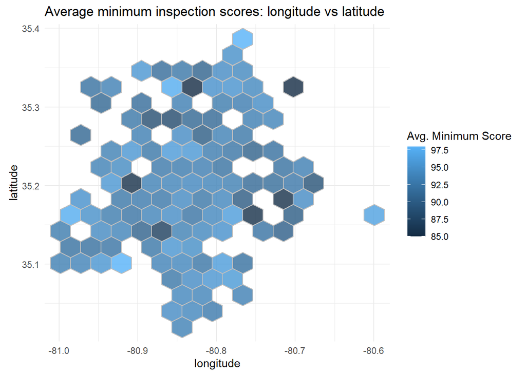

**Inspector IDs**

Some inspectors do seem to grade a bit more harshly than others, but only a few are statistically significant.

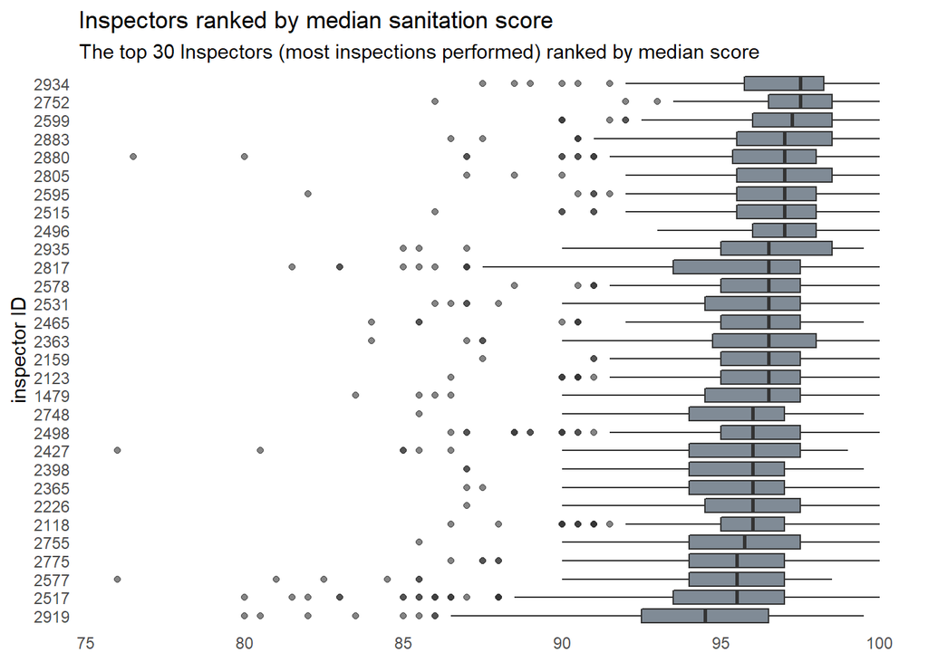

**NLP Plot**

Words most used in inspector comments - a precursor for TF-IDF

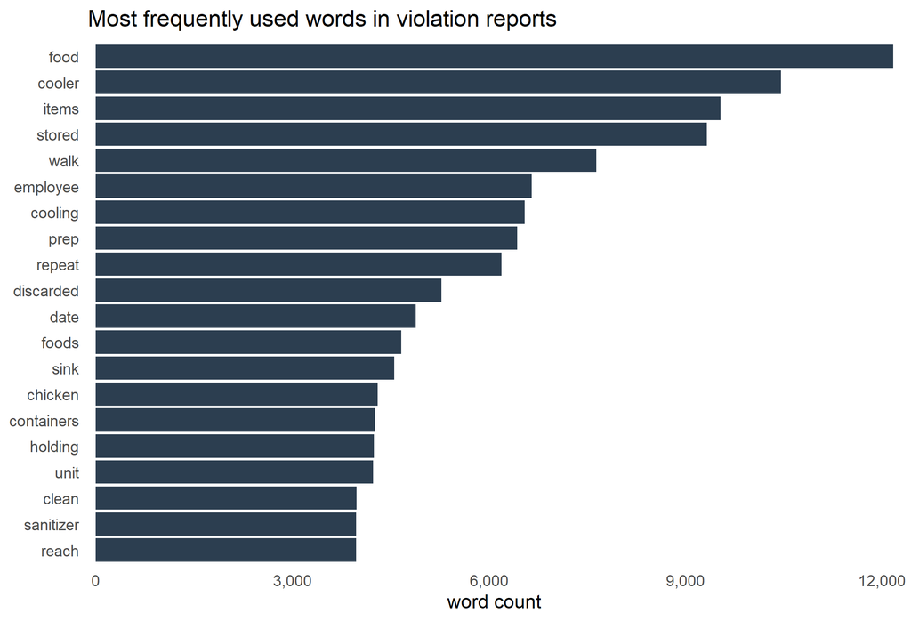

## 7.2 Appendix B: Data Extraction Process

[figure not shown]

[figure not shown]

## 7.3 Appendix C: Full Code Base

```r
#### Load applicable libraries ----

library(tidyverse)
library(tidyr)
library(tm)
library(tidygraph)
library(tidytext)
library(tidyquant)
library(skimr)
library(DataExplorer)
library(rvest)
library(readr)
library(janitor)
library(stringr)
library(readxl)
library(pdftools)
library(tidygeocoder)
library(tmap)
library(tmaptools)
library(viridis)
library(sf)
library(leaflet)
library(maps)
library(mapview)
library(leafpop)
library(RColorBrewer)
library(psych)
library(qwraps2)
library(knitr)
library(gtsummary)
library(htmltools)
library(recipes)
library(text )
library(textrecipes)
library(SnowballC)
library(udpipe)
library(textrank)
library(wordcloud)
library(wordcloud2)
library(reshape2)
library(tm)
library(ggwordcloud)
library(broom)
library(ggrepel)
library(RColorBrewer)
library(gplots)


#### Set options

options(qwraps2_markup = "markdown")
options(scipen = 999)


#### Extract and import rules governing North Carolina sanitation inspections

violation_codes <- read_excel("clt_sanitation_codes.xlsx",sheet = "Sheet3", col_names = TRUE, trim_ws = TRUE) %>% clean_names()


#### Extract raw data ----

restaurants <- read_excel("Source_Files/restaurants_consolidated.xlsx",sheet = 1, col_names = TRUE, trim_ws = TRUE) %>% clean_names() %>% select(-1)
inspections <- read_excel("Source_Files/restaurants_consolidated.xlsx",sheet = 2, col_names = TRUE, trim_ws = TRUE) %>% clean_names() %>% select(-1)
violations <- read_excel("Source_Files/restaurants_consolidated.xlsx",sheet = 3, col_names = TRUE, trim_ws = TRUE) %>% clean_names() %>% select(-1)

#### Create a data dictionary ----

restaurant_colNames <- list(colnames(restaurants))
inspection_colnames <- list(colnames(inspections))
violation_colnames <- list(colnames(violations))
violation_codes_colnames <- list(colnames(violation_codes))

#### Identify data quality issues ----

DataExplorer::plot_missing(restaurants)
DataExplorer::plot_missing(inspections)
DataExplorer::plot_missing(violations)
DataExplorer::plot_missing(violation_codes)

#### more general statistics explorations for outliers and incorrect values

restaurants %>% skimr::skim()
inspections %>% skimr::skim()
violations %>% skimr::skim()



#### Identify initial data quality issues

violations <- violations %>%
    mutate(demerits = ifelse(is.na(demerits), 0, demerits))

restaurants <- restaurants %>%
    filter(state == 'NC')

#### Explore unique identifier performance by RPA bot
#### We notice that there are some violation tables that did not render. Restaurants with inspection scores < 100 should always have at least 1 violation.
#### For our final restaurant list, we'll only we'll only include restaurants with final inspection scores of 100 that TRULY don't have violations


restaurants_no_violations <- restaurants %>%
    inner_join((inspections %>% filter(inspection_score == 100))) %>%
    anti_join(violations) %>% distinct(est_id, name, address, city, state, zip)



violations_undocumented <- inspections %>%
    filter(inspection_score < 100) %>%
    anti_join(violations, by= c('est_id', 'inspection_id')) %>%
    count(est_id, sort = TRUE) %>%
    inner_join(restaurants)

restaurants_final <- restaurants %>%
    semi_join(inspections) %>%
    semi_join(violations) %>%
    rbind(restaurants_no_violations) %>%
    anti_join(violations_undocumented) %>%
    distinct(.)


#### Build a map ----
#### Map our data by first converting restaurant addresses to latitude and longitude points


doParallel::registerDoParallel()


locations <- restaurants %>%
    semi_join(inspections) %>%
    mutate(address = str_glue('{address}',",")) %>%
    mutate(city = str_glue('{city}',",")) %>%
    mutate(full_address = str_c(address,city,state,zip,sep = " ")) %>%
    select(est_id, name, full_address) %>%
    geocode(full_address, method = 'osm', lat = latitude , long = longitude) %>%
    na.omit()

#save the locations file


saveRDS(locations, file="locations.Rda")



#### Plot the restaurants with minimum inspection ratings

min_inspection_ratings <- inspections %>%
    group_by(est_id) %>%
    summarize(min_score = min(inspection_score))




map <- mapview(
    (locations %>% inner_join(min_inspection_ratings)),
    xcol = "longitude",
    ycol = "latitude",
    crs = 4269,
    grid = FALSE,
    zcol = "min_score",
    layer.name = "Minimum Inspection Scores",
    label = "name",
    map.types = "CartoDB.DarkMatter")

#### Construct summary statistic tables ----


set.seed(123)


T1 <- inspections %>%
    inner_join(restaurants %>% select(est_id, name)) %>%
    mutate(year = lubridate::year(inspection_date),
           month = lubridate:: month(inspection_date,label = TRUE, abbr = TRUE)) %>%
    filter(year > 2017) %>%
    mutate(year = as.character(year)) %>%
    select(inspection_grade,year) %>%
    tbl_summary(by = year, label = inspection_grade ~ "Inspection Grade") %>%
    modify_caption("Inspection Grades by Year") %>%
    bold_labels()



T2 <- inspections %>%
    inner_join(restaurants %>% select(est_id, name)) %>%
    mutate(year = lubridate::year(inspection_date),
           month = lubridate:: month(inspection_date,label = TRUE, abbr = TRUE)) %>%
    filter(year > 2017) %>%
    select(inspection_grade,month) %>%
    tbl_summary(by = month, label = inspection_grade ~ "Inspection Grade") %>%
    modify_caption("Inspection Grades by Month") %>%
    bold_labels()


T3 <- inspections %>%
    inner_join(restaurants %>% select(est_id, name)) %>%
    mutate(year = lubridate::year(inspection_date),
           month = lubridate:: month(inspection_date,label = TRUE, abbr = TRUE)) %>%
    filter(year > 2017) %>%
    select(inspection_score) %>%
    tbl_summary(

        type = all_continuous() ~ "continuous2",
        statistic = all_continuous() ~ c("{N_nonmiss}",
                                         "{mean} ({sd})",
                                         "{median} ({p25}, {p75})",
                                         "{min}, {max}"),
        missing = "no"
    ) %>%
    italicize_levels() %>%
    modify_caption("Inspection Scores") %>%
    bold_labels()
```

```r
T4 <- violations %>% select(violation_item,demerits,corrected_during_inspection,repeat_violation,verification_required) %>%
    mutate(violation_item = as.factor(violation_item)) %>%
    tbl_summary() %>%
    modify_caption("Descriptive Statistics for Violations") %>%
    bold_labels()

#### Exploratory data analysis ----
#### Let's do some exploratory analysis and create more visualizations (EDA)

#### Violation counts are related to scores

P1 <- violations %>%
    select(-est_id) %>%
    inner_join((inspections %>% select(-est_id))) %>%
    group_by(inspection_id) %>%
    summarise(score = mean(inspection_score),
              violation_count = n()) %>%
    ggplot(aes(violation_count, score)) +
    geom_jitter(alpha = .2, color = "grey50") +
    geom_smooth(size = 1.5, colour = "#2c3e50") +
    theme_minimal() +
    labs(title = "Number of violations compared to inspections scores",
         subtitle = "As expected, we see a strong negative correlation: restaurants with more violations have lower inspection scores",
         x = "violation count")

#### We know that scores are a direct function of demerits, so let's see if response types have an impact


P2<- violations %>%
    select(demerits,corrected_during_inspection,repeat_violation,verification_required) %>%
    pivot_longer(corrected_during_inspection:verification_required) %>%
    mutate(name = str_replace_all(name,"_"," ") %>% str_to_title()) %>%
    mutate_if(is.character,factor) %>%
    mutate(demerits = factor(as.character(demerits))) %>%
    ggplot(aes(demerits, fill = value)) +
    geom_bar(position = "fill", alpha = .9) +
    scale_fill_manual(values = c("grey80","#2c3e50")) +
    scale_y_continuous(labels = scales::percent,
                       n.breaks = 3,expand = c(.02,.02)) +

    coord_flip() +
    theme_minimal() +
    theme(strip.text.x = element_text(size = 10,face = "bold"),
          axis.text.y = element_text(size = 12),
          panel.grid.major = element_blank(),
          panel.grid.minor = element_blank(),
          legend.position = c(.04,.9999),legend.direction = "horizontal")+

    guides(fill = guide_legend(reverse = TRUE)) +
    facet_wrap(~name, scales = "free_x") +
    labs(title = "Violations with higher demerits typically are REPEAT VIOLATIONS and must be CORRECTED DURING INSPECTION",
         subtitle = "Demerits represent the number of points deducted from inspection scores",
         x = NULL,
         y = NULL,
         fill = NULL)



#### Does location impact restaurant inspection scores?

P3 <- locations %>%
    inner_join(min_inspection_ratings) %>%
    ggplot(aes(longitude, latitude, z = min_score)) +
    stat_summary_hex(color = "grey", alpha = .8, bins = 15) +
    scale_color_tq() +
    labs(fill = "Avg. Minimum Score") +
    theme_minimal() +
    coord_fixed() +
    labs(title = "Average minimum inspection scores: longitude vs latitude",
         subtitle = "There could possibly be some areas within Charlotte, NC where restaurants typically receive lower sanitation scores")



#### Let's take a look at violation items to see if there are differences in avg demerits per violation

P4 <- violations %>%
    arrange(violation_item) %>%
    mutate(number = as.character(violation_item)) %>%
    ggplot(aes(factor(violation_item,ordered = TRUE), demerits, color = "identity")) +
    geom_jitter(width = .2, alpha= .1) +
    coord_flip()+
    scale_color_tq() +
    theme_minimal() +
    theme(legend.position = "none") +
    labs(title = "Demerits by violation item",
         subtitle = "items x are the largest",
         x = "Violation Item")


#### Do certain inspectors grade more harshly than others

top_inspectors <- inspections %>%
    group_by(inspector_id) %>%
    summarize(avg_ins_rating = mean(inspection_score),
              count = n()) %>%
    ungroup() %>%
    slice_max(order_by = count,n = 30) %>%
    arrange(avg_ins_rating) %>% pull(inspector_id)

#### plot the inspector IDs and rank by median rating

P5 <- inspections %>%
    filter(inspector_id %in% top_inspectors) %>%
    mutate(inspector_id = as.factor(inspector_id)) %>%
    ggplot(aes(fct_reorder(inspector_id,inspection_score,.desc = FALSE), inspection_score)) +
    coord_flip() +
    scale_x_discrete()+
    geom_boxplot(fill = "#2c3e50", alpha = .6) +
    labs(y = NULL,
         x = "Inspector ID",
         title = "Inspectors ranked by median sanitation score",
         subtitle = "The top 30 Inspectors (most inspections performed) ranked by median score provided to restaurants ") +
    theme_minimal() +
    theme(panel.grid.major = element_blank(),
          panel.grid.minor = element_blank())



#### Data wrangling ----

#### Now that we have some generic plots, let's do some data wrangling

#### For violations, we'd like to separate the inspector comments from violation numbers AND only use "observations" from the inspectors

pattern_num <- "(\\d+)-(\\d+).(\\d+)"
pattern_obs <- "(observed|Observed).+"


#### final violations table used for NLP analysis
violations_NLP <- violations %>%
    mutate(violation_number = str_extract(inspector_comments,pattern = pattern_num) %>% str_trim(),
           observations = str_extract(inspector_comments,pattern = pattern_obs) %>% str_trim() %>% str_remove_all("(observed|Observed|-P)")) %>%
    filter(!is.na(violation_number)) %>%
    filter(!is.na(observations)) %>% select(-inspector_comments)


#### NLP ----

words_cleaned <- violations_NLP %>%
    unnest_tokens(word, observations) %>%
    anti_join(stop_words) %>%
    mutate(word = str_extract(word, "[a-z']+")) %>%
    filter(!is.na(word)) %>%
    # remove abbreviations and
    filter(str_length(word) > 3) %>%
    # remove punctuation
    mutate(word = str_remove_all(word, pattern = "[[:punct:]]"))


#### make a quick plot of frequent words in observations
P6 <- words_cleaned %>%
    count(word, sort = TRUE) %>%
    slice_max(n = 20, order_by = n) %>%
    mutate(word = reorder(word,n)) %>%
    ggplot(aes(n, word)) +
    geom_col(fill = "grey80") +
    theme_minimal() +
    scale_x_continuous(expand = c(.01,0),labels = scales::comma) +
    theme(strip.text.x = element_text(size = 10),
          panel.grid.major = element_blank(),
          panel.grid.minor = element_blank()) +
    labs(x = "Count",
         y = NULL,
         title = "Most frequently used words in violation reports")
```

```r
#### Let's jump right into TF-IDF to determine words specific to each categories

### split by very high scores and very low scores
set.seed(123)

P7 <- words_cleaned %>%
    inner_join(inspections) %>%
    mutate(performance = case_when(inspection_score > 99 ~ "very high",
                                   inspection_score > 84 ~ "mediocre",
                                   TRUE ~ "very low")) %>%
    filter(performance != "mediocre") %>%
    count(performance, word, sort = TRUE) %>%
    ungroup() %>%
    bind_tf_idf(word,performance, n) %>%
    arrange(-tf_idf) %>%
    group_by(performance) %>% mutate(performance = factor(performance)) %>%
    slice_max(n = 20,with_ties = FALSE, order_by = tf_idf) %>%
    mutate(word = factor(word, levels = rev(unique(word)))) %>%
    ggplot(aes(word,tf_idf, fill = performance)) +
    geom_col(alpha = .8,show.legend = FALSE) +
    scale_fill_tq() +
    labs(title = "Words most associated with very high scores vs. very low scores",
         subtitle = "The below chart shows the top 15 words associated with very high inspection scores vs. very low inspections scores using tf-idf",
         x = NULL,
         y = "tf-idf") +
    facet_wrap(~performance, scales = "free") +
    coord_flip() +
    theme_minimal()  +
    theme(panel.grid.major = element_blank(),
          panel.grid.minor = element_blank())


#### Text rank model using Google's Page Rank algorithm to summarize violation observations - this will be used later

ud_model <- udpipe_download_model(language = "english")
ud_model <- udpipe_load_model(ud_model$file_model)

#### filter by violations that have demerits > 2, since inspection scores are a direct function of demerits given
# high_demerits <- violations_NLP %>%
#     filter(demerits > 2) %>%
#     mutate(observations = str_to_lower(observations))
#
#
# low_demerits <- violations_NLP %>%
#     filter(demerits == 0) %>%
#     sample_n(size = 2000) %>%
#     mutate(observations = str_to_lower(observations))
#
# #### run model for high demerits: 3 or 4
#
# x <- udpipe_annotate(ud_model, x = high_demerits$observations)
# x <- as.data.frame(x)
#
# stats <- textrank_keywords(x$lemma,
#                            relevant = x$upos %in% c("NOUN", "ADJ"),
#                            ngram_max = 8, sep = " ")
#
# stats <- subset(stats$keywords, ngram > 1 & freq >= 20)
#
# stats <- stats %>%
#     slice_max(n=100,order_by = freq) %>% select(-ngram)
#
# #### run model for low demerits
#
# y <- udpipe_annotate(ud_model, x = low_demerits$observations)
# y <- as.data.frame(y)
#
# stats2 <- textrank_keywords(y$lemma,
#                             relevant = y$upos %in% c("NOUN", "ADJ"),
#                             ngram_max = 8, sep = " ")
#
# stats2 <- subset(stats2$keywords, ngram > 1 & freq >= 10)
#
# stats2 <- stats2 %>%
#     slice_max(n=100,order_by = freq) %>% select(-ngram)
#
# comparison <- stats %>% mutate(demerits = "High") %>%
#     rbind(stats2 %>% mutate(demerits = "Low"))


set.seed(123)


#### determine feature significance and direction. For restaurants that had matching violation IDs and score < 90, none had a max violation below 1.5 demerits
inspections %>%
    filter(inspection_score < 90) %>%
    inner_join(violations, by = c("inspection_id" = "inspection_id")) %>%
    group_by(inspection_id) %>%
    summarize(max_demerits = max(demerits)) %>%
    arrange(-max_demerits) %>% view()

#### predictive modeling


sample <- violations %>%
    inner_join(locations) %>%
    select(corrected_during_inspection,verification_required,repeat_violation,violation_item, demerits, latitude,longitude) %>%
    mutate_if(is.character,factor)

### quick linear model to determine feature inclusion outside text and

linear_model <- lm(demerits ~.,data = sample)

summary(linear_model)

#### Out of the 8 categories, food has most violations

violations_model_df <- violations_NLP %>%
    mutate(violation_number = str_sub(violation_number,1,5)) %>%
    inner_join(violation_codes,by = c("violation_number" = "code_subtitle"))



P9 <- violations_model_df %>%
    mutate(demerits = factor(as.character(demerits))) %>%
    count(chapter_description,demerits,sort = TRUE) %>%
    ungroup() %>%
    mutate(chapter_description = reorder(chapter_description,n)) %>%
    ggplot(aes(chapter_description, n, fill = demerits)) +
    scale_fill_tq() +
    geom_col() +
    theme_minimal() +
    coord_flip()



violations_model_df %>%
    mutate(demerits = factor(as.character(demerits))) %>%
    filter(demerits == '4') %>%
    count(chapter_description,demerits)

P10 <- violations_model_df %>%
    mutate(demerits = factor(as.character(demerits))) %>%
    count(sub_chapter_description,demerits,sort = TRUE) %>%
    ungroup() %>%
    mutate(sub_chapter_description = reorder(sub_chapter_description,n)) %>%
    ggplot(aes(sub_chapter_description, n, fill = demerits)) +
    scale_fill_tq() +
    geom_col() +
    theme_minimal() +
    coord_flip()


#### for cluster analysis, we'll only include count of violations 4 or greater
lowcounts <- violations %>%
    group_by(inspection_id) %>%
    count(inspection_id) %>% filter(n <4)




#### Clean up the description data



#### dummy table for additional features
dummy_table <- violations_model_df %>%
    transmute(inspection_id,repeat_violation = ifelse(repeat_violation == 'Yes',1,0),
              corrected_during_inspection = ifelse(corrected_during_inspection == 'Yes',1,0),
              verification_required = ifelse(verification_required == 'Yes',1,0),
              demerit_0 = ifelse(demerits == 0, 1,0),
              demerit_.5 = ifelse(demerits == 0.5, 1,0),
              demerit_1 = ifelse(demerits == 1, 1,0),
              demerit_1.5 = ifelse(demerits == 1.5, 1,0),
              demerit_2 = ifelse(demerits == 2, 1,0),
              demerit_3 = ifelse(demerits == 3, 1,0),
              demerit_4 = ifelse(demerits == 4, 1,0)) %>%
    group_by(inspection_id) %>%
    mutate(count = n()) %>%
    mutate(
        across(c(2:10),
               .fns = ~./count)) %>% ungroup() %>%
    group_by(inspection_id) %>%
    summarise_at(1:10,sum)
#### we have to add one more catch in here for violations that have all repeats inflating the counts and remove low counts
dummy_table <- dummy_table %>%
    mutate(repeat_violation = ifelse(repeat_violation > 1, 1,repeat_violation)) %>%
    anti_join(lowcounts)
```

```r
#### let's combine our dummy table with our kmeans table to get all features together



 kmeans_tbl <- violations_model_df %>%
mutate(violation_description = str_to_lower(violation_description)) %>%
mutate(violation_description = str_replace_all(violation_description,pattern = "&",replacement = "and")) %>%
mutate(violation_description = tm::removePunctuation(violation_description)) %>%
# #
# #
# #
# #   mutate(violation_description = str_replace_all(violation_description,pattern = ",",replacement = "")) %>%
# #   group_by(inspection_id) %>%
# #   mutate(count = n()) %>%
# #   ungroup() %>%
# #   group_by(inspection_id, violation_description) %>%
# #   summarize(perc = n()/ count) %>%
# #   pivot_wider(names_from = violation_description, values_from = perc, values_fill = 0) %>%
# #   inner_join(dummy_table) %>%
# #   ungroup()
#
# #
# # ### perform k means clustering
# #
# # set.seed(123)
# #
# # kmeans_obj <- kmeans_tbl %>%
# #   select(-inspection_id) %>%
# #   kmeans(centers = 2, nstart = 25)
# #
# # tidy(kmeans_obj) %>% view()
# #
# # #### this was just a start, so let's see what the optimal number of groups should be with a skree plot
# #
# # kmeans_tbl2 <- kmeans_tbl %>% select(-inspection_id)
# #
# # set.seed(123)
# #
# # #### function to compute total within-cluster sum of square
# # wss <- function(k) {
# #   kmeans(kmeans_tbl2, k, nstart = 10 )$tot.withinss
# # }
# #
# # #### Compute and plot wss for k = 1 to k = 15
# # k.values <- 1:15
# #
# # #### extract wss for 2-15 clusters
# # wss_values <- map_dbl(k.values, wss)
# #
# # plot(k.values, wss_values,
# #      type="b", pch = 19, frame = FALSE,
# #      xlab="Number of clusters K",
# #      ylab="Total within-clusters sum of squares")
# #
# # ### as we can see, kmeans didn't work well with the sparse matrix and large variety. Let's describe by demerits



### clean the violation description column

violations_summary_tbl <- violations_model_df %>%
    mutate(violation_description = str_to_lower(violation_description)) %>%
    mutate(violation_description = str_replace_all(violation_description,pattern = "&",replacement = "and")) %>%
    mutate(violation_description = tm::removePunctuation(violation_description)) %>%
    mutate(violation_description = str_replace_all(violation_description,"nonfoodcontact","nonfood contact")) %>%
    mutate(violation_description = str_replace_all(violation_description,"raw or undercooked foods","raw undercooked foods")) %>%
    mutate(violation_description = str_replace_all(violation_description,"management and food employee knowledge and conditional employee responsibilities and reporting",
                                                   "management food and conditional employee knowledge responsibilities and reporting")) %>%
    mutate(violation_description = str_replace_all(violation_description,"no bare hand contact with rte foods or pre approved alternate procedure properly followed",
                                                   "no bare hand contact with rte foods or a preapproved alternate properly followed")) %>%


    mutate(violation_description = str_replace_all(violation_description,pattern = ",",replacement = "")) %>%
    mutate(demerits = factor(as.character(demerits)))%>%
    group_by(violation_description, demerits) %>%
    summarise(n = n()) %>%
    mutate(prop = n/ sum(n)) %>%
    select(-prop) %>%
    pivot_wider(names_from = demerits, values_from = n,values_fill = 0) %>%
    ungroup() %>%
    mutate("desc_total" = rowSums((.[,2:8]), na.rm = TRUE)) %>% filter(desc_total > 6) %>%
    mutate("total" = sum(desc_total),
           "total_perc" = desc_total / total) %>%
    pivot_longer(2:8) %>%
    mutate(desc_perc = value / desc_total)



#### let's do some proportional analysis to see how two the groups differ


P10 <- inspections %>%
    inner_join(violations,by = c("inspection_id" = "inspection_id")) %>%
    mutate(high_score = ifelse(inspection_score < 90, "score < 90", "score >= 90")) %>%
    mutate(demerits = factor(as.character(demerits))) %>%
    group_by(high_score, demerits) %>%
    summarize(count = n()) %>%
    mutate(perc = sum(count) / count) %>%
    ggplot(aes(high_score,count, fill = demerits)) +
    geom_col(position = "fill",alpha = .8) +
    coord_flip() +
    scale_fill_brewer(palette = 'Reds') +
    scale_y_continuous(labels=scales::percent) +
    #scale_x_continuous(labels=scales::percent) +
    theme_minimal() +
    theme(panel.grid.major = element_blank(),
          panel.grid.minor = element_blank()) +
    labs(title = "proportion of demerits between inspection scores greater than 90 vs scores less than 90",
         subtitle = "Restaurants who received scores of less than 90 have a much higher proportion of larger demerits (2,3,4)",
         x = NULL,
         y = NULL,
    )


#### to dive in a bit deeper, let's take the top culprits for higher demerits (2,3,4) and highlight them

high_demerit_culprits <- violations_summary_tbl %>% filter(name > 1.5) %>%
    mutate(rank = total_perc * desc_perc) %>%
    arrange(-rank) %>%
    head(7) %>%
    bind_rows(violations_summary_tbl %>% filter(violation_description == "hands clean and properly washed" & name == 4 ))

low_demerit_culptrits <- violations_summary_tbl %>% filter(name > 1.5) %>%
    filter(!violation_description %in% high_demerit_culprits$violation_description) %>%
    filter(name %in% c(2,3,4)) %>%
    filter(desc_perc > 0.04)


#### plot the results and highlight top 10 culprits


P11 <- violations_summary_tbl %>%
    filter(name %in% c(2,3,4)) %>%
    filter(desc_perc > 0.04) %>%
    ggplot(aes(total_perc, desc_perc, shape = name, color = "gray80")) +
    geom_point(data=low_demerit_culptrits,
               aes(x=total_perc,y=desc_perc),
               color= "gray80",
               size = 1.5,alpha = .95, size = 2) +
    geom_point(data=high_demerit_culprits,
               aes(x=total_perc,y=desc_perc),
               color= "indianred",
               size = 3) +
    geom_text_repel(data = low_demerit_culptrits,
                    aes(label = violation_description),
                    color = "gray80",
                    size = 2.5,alpha = .95) +
    geom_text_repel(data=high_demerit_culprits,
                    aes(label = violation_description),nudge_y = -.015,
                    size = 3.5,
                    color= "indianred") +
```

```r
    scale_color_tq() +
    scale_y_continuous(limits = c(0,1),labels=scales::percent) +
    scale_x_continuous(limits = c(0, .08),labels=scales::percent) +
    labs(title = "Which violation descriptions account for high demerits?",
         subtitle = "Violation descriptions: proportion of total violation descriptions X proportion of violation descriptions by demerit type",
         x = "proportion of total violation descriptions",
         y = "proportion of demerit types",
         shape  = "demerits",
         color = NULL) +
    theme_minimal() +
    theme(panel.grid.major = element_blank(),
          panel.grid.minor = element_blank())







#### check out specific violations and plot them

violations_subcode_tbl <- violations_model_df %>%
    mutate(violation_description = str_to_lower(violation_description)) %>%
    mutate(violation_description = str_replace_all(violation_description,pattern = "&",replacement = "and")) %>%
    mutate(violation_description = tm::removePunctuation(violation_description)) %>%
    mutate(violation_description = str_replace_all(violation_description,"nonfoodcontact","nonfood contact")) %>%
    mutate(violation_description = str_replace_all(violation_description,"raw or undercooked foods","raw undercooked foods")) %>%
    mutate(violation_description = str_replace_all(violation_description,"management and food employee knowledge and conditional employee responsibilities and reporting",
                                                   "management food and conditional employee knowledge responsibilities and reporting")) %>%
    mutate(violation_description = str_replace_all(violation_description,"no bare hand contact with rte foods or pre approved alternate procedure properly followed",
                                                   "no bare hand contact with rte foods or a preapproved alternate properly followed")) %>%


    mutate(violation_description = str_replace_all(violation_description,pattern = ",",replacement = "")) %>%
    mutate(demerits = factor(as.character(demerits))) %>%
    filter(violation_description %in% high_demerit_culprits$violation_description) %>%
    mutate(demerits = case_when(demerits == '4'~ 4,
                                demerits == '3'~ 3,
                                demerits == '2'~ 2,
                                demerits == '1'~ 1,
                                demerits == '1.5'~ 1.5,
                                demerits == '.5'~ .5,
                                TRUE ~ 0)) %>%
    group_by(chapter_description, violation_number) %>%
    summarise(n = n(),
              mean = round(mean(demerits),2),
              sdev = sd(demerits),
              lower = mean - (1*sdev),
              upper = mean +(1*sdev)) %>%
    filter(n > 50) %>%
    filter(mean > .7)

P12 <- violations_subcode_tbl %>%
    ggplot(aes(reorder(violation_number,mean),mean, color = chapter_description, ymin = lower, ymax = upper)) +
    geom_pointrange(size = 1,alpha = .8) + coord_flip() +
    labs(x = "violation sub code", y = "Average Demerits",
         color = "Chapter Description") +
    geom_hline(yintercept = 1,linetype = 2,size = 1.2, color = "gray80") +
    geom_text(aes(label = str_glue("N: {scales::comma(n)}
                                 Avg: {mean}")), size = 2.5,nudge_x = .28, nudge_y = .18) +
    theme_minimal() +
    theme(panel.grid.major = element_blank(),
          panel.grid.minor = element_blank()) +
    scale_color_tq() +
    labs(title = "Which violation sub-codes typically have the highest demerits?",
         subtitle = "Top 10 critical violation codes: PRIORITIZE for inspection readiness")

#### let's make one last word cloud for each of these categories


final_demerits_wc <- violations_model_df %>%
    mutate(violation_description = str_to_lower(violation_description)) %>%
    mutate(violation_description = str_replace_all(violation_description,pattern = "&",replacement = "and")) %>%
    mutate(violation_description = tm::removePunctuation(violation_description)) %>%
    mutate(violation_description = str_replace_all(violation_description,"nonfoodcontact","nonfood contact")) %>%
    mutate(violation_description = str_replace_all(violation_description,"raw or undercooked foods","raw undercooked foods")) %>%
    mutate(violation_description = str_replace_all(violation_description,"management and food employee knowledge and conditional employee responsibilities and reporting",
                                                   "management food and conditional employee knowledge responsibilities and reporting")) %>%
    mutate(violation_description = str_replace_all(violation_description,"no bare hand contact with rte foods or pre approved alternate procedure properly followed",
                                                   "no bare hand contact with rte foods or a preapproved alternate properly followed")) %>%


    mutate(violation_description = str_replace_all(violation_description,pattern = ",",replacement = "")) %>%
    mutate(demerits = factor(as.character(demerits))) %>%
    filter(violation_description %in% high_demerit_culprits$violation_description) %>%
    filter(demerits %in% c(2,3,4))


#### run model for high demerits: 2,3 or 4

z <- udpipe_annotate(ud_model, x = final_demerits_wc$observations)
z <- as.data.frame(z)

stats3 <- textrank_keywords(z$lemma,
                            relevant = z$upos %in% c("NOUN", "ADJ"),
                            ngram_max = 8, sep = " ")

stats3 <- subset(stats3$keywords, ngram > 1 & freq >= 10)

stats3 <- stats3 %>%
    top_n(100) %>% select(-ngram) %>%
    filter(!keyword %in% c("could hold","walk in","reach in","food in","could hold","don glove","item in")) %>%
    mutate(keyword = ifelse(str_detect(str_to_lower(keyword),"tc"),"TCS Food Item",keyword)) %>%
    group_by(keyword) %>%
    summarize(freq = sum(freq)) %>%
    arrange(-freq)

#### save the final model

#saveRDS(stats3, file="google_model_df.Rda")


#### plot in final word cloud

set.seed(123)
```

```r
P13 <- ggplot(stats3,
             aes(label = keyword,
                 size = freq)) +
    geom_text_wordcloud_area(color = "indianred") +
    scale_size_area(max_size = 40) +
    theme_minimal()

#### now that we know which specific violations represent the highest demerits, let's bring in the reference table

severe_violations_tbl_reference <- violation_codes %>%
    filter(code_subtitle %in% violations_subcode_tbl$violation_number)

specific_violations <- violations%>%
    mutate(long_number = str_extract(inspector_comments,pattern = pattern_num) %>% str_trim()) %>%
    mutate(short_number = str_sub(long_number,1,5)) %>%
    filter(short_number %in% severe_violations_tbl_reference$code_subtitle) %>%
    group_by(short_number,long_number) %>%
    summarize(n = n(),
              mean = mean(demerits)) %>%
    arrange(-mean) %>%
    filter(n >= 50) %>% filter(mean >1) %>%
    arrange(short_number,long_number)

final_reference_tbl <- severe_violations_tbl_reference %>%
    inner_join(specific_violations, by = c("code_subtitle" ="short_number")) %>% select(-n) %>% select(-mean) %>%
    head(12)


#### find the sub code descriptions and bind to reference table

subcode_desc <- tibble(subcode_descripton =
                           c("ASSIGNMENT", "DEMONSTRATION", "CERTIFIED FOOD PROTECTION MANAGER",
                             "CLEANING PROCEDURE", "WHEN TO WASH","PACKAGED AND UNPACKAGED FOOD",
                             "GLOVES - USE LIMITATION","COOLING","TIME AND TEMPERATURE CONTROL FOR SAFETY FOOD",
                             "READY TO EAT TIME AND TEMPERATURE CONTROL FOR SAFETY FOOD: DATE MARKING",
                             "READY TO EAT TIME AND TEMPERATURE CONTROL FOR SAFETY FOOD: DISPOSITION",
                             "EQUIPMENT, FOOD CONTACT SURFACES, NONFOOD CONTACT, AND UTENSILS"))


final_reference_tbl <- final_reference_tbl %>%
    rename("subcode" = long_number) %>%
    bind_cols(subcode_desc) %>%
    mutate(sub_chapter = ifelse(str_detect(sub_chapter,'4-5'),'4-6',sub_chapter)) %>%
    mutate(sub_chapter_description = ifelse(str_detect(sub_chapter_description,'MAINTENANCE AND OPERATION'),'CLEANING OF EQUIPMENT AND UTENSILS',sub_chapter_description))%>%
    mutate(code_subtitle = ifelse(str_detect(code_subtitle,'4-501'),'4-601',code_subtitle)) %>%
    mutate(code_description = ifelse(str_detect(code_description,'EQUIPMENT'),'OBJECTIVE',code_description)) %>%
    mutate(subcode = ifelse(str_detect(subcode,'4-501.112'),'4-601.11',subcode))
```